# Vizgen MERSCOPE. Analysis of Image-based Spatial Data in Seurat

2023-01-24

# Overview

The Seurat extension to analyze new types of spatially-resolved data. These approaches also often capture cellular boundaries (segmentations).

Install the updated versions of Seurat and SeuratObject that support this infrastructure, as well as other packages necessary for this analysis.

```r
# library(remotes) remotes::install_github('satijalab/seurat', 'feat/imaging')
library(Seurat)
library(hdf5r)
library(future)
library(glmGamPoi)
plan("multisession", workers = 10)
```

# Human Liver Cancer: Vizgen MERSCOPE

Read in the dataset and create a Seurat object.

We use the `LoadVizgen()` function to read in the output of the Vizgen analysis pipeline. The resulting Seurat object contains the following information:

```r
# Loading segmentations is a slow process and multi processing with the future pacakge is
# recommended
setwd("/media/Lena/Vizgen")
vizgen.obj <- LoadVizgen(data.dir = getwd(), fov = "Human_liver_cancer1", assay = "Analysis")
```

```r
analysis <- saveRDS(vizgen.obj, file = "analysis.RDS")
```

```r
analysis <- readRDS("analysis.RDS")
```

Storing in the images slot of the resulting Seurat object:

Cell Centroids: The spatial coordinates marking the centroid for each cell being profiled

One cell has no UMI Filtering the cell out

```r
min(analysis$nCount_Analysis)
```

```
## [1] 0
```

```r
analysis <- subset(analysis, nCount_Analysis > 0)
```

# Get the center position of each centroid. There is one row per cell in this dataframe.

```r
head(GetTissueCoordinates(analysis[["Human_liver_cancer1"]][["centroids"]]))
```

```
##          x         y cell
## 1 8523.484 -88.12665    1
## 2 8498.600 -87.94176    5
## 3 8368.861 -85.98395    6
## 4 8397.214 -88.28067    7
## 5 8406.587 -87.30772    8
## 6 8442.058 -85.60723    9
```

Cell Segmentation Boundaries: The spatial coordinates that describe the polygon segmentation of each single cell

```r
# Get the coordinates for each segmentation vertice. Each cell will have a variable number of
# vertices describing its shape.
head(GetTissueCoordinates(analysis[["Human_liver_cancer1"]][["segmentation"]]))
```

```
##          x         y cell
## 1 8520.873 -94.50473    1
## 2 8518.061 -94.16357    1
## 3 8517.379 -93.70859    1
## 4 8516.507 -90.30072    1
## 5 8516.720 -88.65731    1
## 6 8517.770 -86.52201    1
```

Molecule positions: The spatial coordinates for each individual molecule that was detected during the multiplexed smFISH experiment.

```r
# Fetch molecules positions for Chrm1
head(FetchData(analysis[["Human_liver_cancer1"]][["molecules"]], vars = "Chrm1"))
```

[output not shown]

## Preprocessing and unsupervised analysis

We start by performing a standard unsupervised clustering analysis, essentially first treating the dataset as an scRNA-seq experiment. We use SCTransform-based normalization, though we slightly modify the default clipping parameters to mitigate the effect of outliers that we occasionally observe in smFISH experiments. After normalization, we can run dimensional reduction and clustering.

Biological heterogeneity in single-cell RNA-seq data is often confounded by technical factors including sequencing depth. The number of molecules detected in each cell can vary significantly between cells, even within the same celltype. Interpretation of scRNA-seq data requires effective pre-processing and normalization to remove this technical variability. In Hafemeister and Satija, 2019 we introduce a modeling framework for the normalization and variance stabilization of molecular count data from scRNA-seq experiment. This procedure omits the need for heuristic steps including pseudocount addition or log-transformation and improves common downstream analytical tasks such as variable gene selection, dimensional reduction, and differential expression.

```r
# each worker needs access to certain global variables. If these are larger than the default
# limit,we use this
options(future.globals.maxSize = 8000 * 1024^2)

# Using sctransform based normalization enables recovering sharper biological distinction
# compared to log-normalization
vizgen.obj <- SCTransform(analysis, assay = "Analysis", vst.flavor = "v2", clip.range = c(-10, 10),
    )
vizgen.obj <- RunPCA(vizgen.obj, npcs = 30, features = rownames(vizgen.obj))
```

```r
vizgen.obj <- RunUMAP(vizgen.obj, dims = 1:30)
```

```r
vizgen.obj <- FindNeighbors(vizgen.obj, reduction = "pca", dims = 1:30)
```

```r
vizgen.obj <- FindClusters(vizgen.obj, resolution = 0.2)
```

[output not shown]

Visualizing the results of the clustering either in UMAP space (with `DimPlot()`) or overlaid on the image with `ImageDimPlot()`.

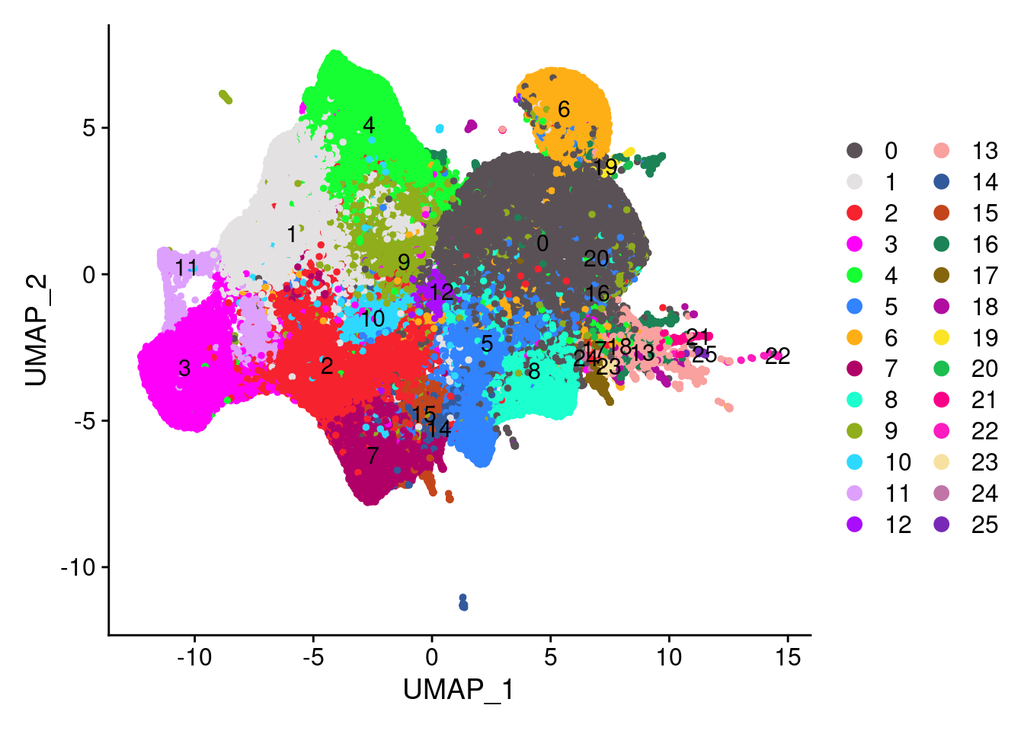

```r
# install.packages('scCustomize')
library(scCustomize)
DimPlot_scCustom(vizgen.obj, reduction = "umap", raster = F)
```

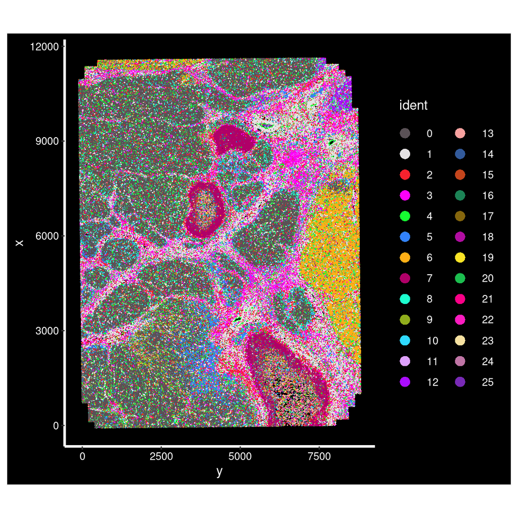

```r
library(pals)
ImageDimPlot(vizgen.obj, fov = "Human_liver_cancer1", cols = "polychrome", axes = TRUE)
```

```r
vizgen.obj <- saveRDS(vizgen.obj, file = "analysis2.RDS")
```

```r
vizgen.obj <- readRDS("analysis2.RDS")
```

```r
library(tidyr)
library(scCustomize)
analysis.markers <- FindAllMarkers(vizgen.obj, only.pos = TRUE, min.pct = 0.25, logfc.threshold = 0.01) %>%
    Add_Pct_Diff()
```

```r
library(dplyr)
analysis.markers %>%
    group_by(cluster) %>%
    slice_max(n = 2, order_by = avg_log2FC) %>%
    print(n = 60)
```

```
## # A tibble: 52 × 8
## # Groups:   cluster [26]
##        p_val avg_log2FC pct.1 pct.2 p_val_adj cluster gene     pct_diff
##        <dbl>      <dbl> <dbl> <dbl>     <dbl> <fct>   <chr>       <dbl>
##  1 0              1.30  0.998 0.865 0         0       GPX3       0.133
##  2 0              1.08  1     0.82  0         0       VTN        0.18
##  3 0              2.88  0.996 0.711 0         1       COL1A1     0.285
##  4 0              2.09  0.712 0.242 0         1       ACTA2      0.47
##  5 0              2.03  0.942 0.562 0         2       HLA-DRA    0.38
##  6 0              1.85  0.741 0.191 0         2       C1QC       0.55
##  7 0              2.24  0.829 0.155 0         3       CXCR4      0.674
##  8 0              2.07  0.771 0.045 0         3       TRAC       0.726
##  9 0              2.88  0.836 0.124 0         4       PLVAP      0.712
## 10 0              2.26  0.59  0.068 0         4       VWF        0.522
## 11 0              1.58  0.332 0.054 0         5       MMP7       0.278
```

[output cut: 41 more lines]

```r
analysis <- saveRDS(vizgen.obj, file = "analysis3.RDS")
```

```r
analysis <- readRDS("analysis3.RDS")
```

```r
# install.packages('scCATCH')
library(scCATCH)
vizgen.obj_RNA <- RenameAssays(vizgen.obj, SCT = "RNA")
```

```r
library(scater)
library(scuttle)
Idents(vizgen.obj_RNA) <- vizgen.obj_RNA@meta.data$seurat_clusters
vizgen.obj_RNA_SCE <- as.SingleCellExperiment(vizgen.obj_RNA)
vizgen.obj_RNA_SCE <- scuttle::logNormCounts(vizgen.obj_RNA_SCE)
vizgen.obj_RNA_SCE_mat <- counts(vizgen.obj_RNA_SCE)
```

```r
vizgen.obj_RNA_SCE_mat2 <- rev_gene(vizgen.obj_RNA_SCE_mat, data_type = "data", species = "Human",
    geneinfo = geneinfo)
```

```r
obj <- createscCATCH(data = vizgen.obj_RNA_SCE_mat2, cluster = as.character(vizgen.obj_RNA@meta.data$seurat_clusters))
```

```r
obj <- findmarkergene(object = obj, species = "Human", marker = cellmatch, tissue = "Liver")
```

```r
rownames(obj@data$ndata)[1:10]
```

```
##  [1] "PDK4"     "CCL26"    "CX3CL1"   "PGLYRP1"  "CD4"      "SNAI2"
##  [7] "TNFRSF17" "ICAM3"    "TBX21"    "FAP"
```

```r
obj <- findcelltype(obj)
```

```r
obj@celltype$cluster
```

```
## [1] "4"  "2"  "6"  "1"  "7"  "3"  "12" "11"
```

```r
obj@celltype$cluster_marker
```

```
## [1] "DUSP1, VWF, KDR, ENG, PECAM1"        "FCGR2A, CD14, MRC1"
## [3] "ARG1, PRF1"                          "ACTA2, PDGFRA, ITGA1"
## [5] "PKM, ITGB2"                          "GZMA, CD3D, PTPRC, CD8A, CD3E, CCL5"
## [7] "BST2, ITGB1, SOD2"                   "CD79A, MS4A1, CD19, CD27"
```

```r
obj@celltype$cell_type
```

```
## [1] "Endothelial Cell"      "Monocyte"              "Hepatocyte, T Cell"
## [4] "Myofibroblast"         "Kupffer Cell, T Cell"  "Cytotoxic T Cell"
## [7] "Mesenchymal Stem Cell" "B Cell"
```

```r
obj2 <- findmarkergene(object = obj, species = "Human", cancer = "Liver Cancer", marker = cellmatch,
    tissue = "Liver")
```

```r
obj2 <- findcelltype(obj2)
```

```r
obj2@celltype$cluster
```

```
## [1] "12"
```

```r
obj2@celltype$cluster_marker
```

```
## [1] "ICAM1"
```

```r
obj2@celltype$cell_type
```

```
## [1] "Stem Cell"
```

#defining clusters 0 GPX3 Fibroblasts 0 VTN Cancer Hepatocytes

1 COL1A1z 1 ACTA2 Myofibroblast

2 HLA-DRA 2 C1QC T cell

3 CXCR4 3 TRAC Cytotoxic T Cell

4 PLVAP 4 VWF Endothelial Cell

5 MMP7 Cholangiocyte 5 LYZ Monocytes

6 VTN Hepatocytes 6 IDH1 Monocytes

IDH1 is abundant in liver and was reported to participate in lipid biosynthesis in hepatocyte cytoplasm and peroxisomes DH1 and IDH2 mutations have been identified in multiple tumor types

7 SPP1 Epithelial 7 MMP9 Neutrophils

8 MYBL2 8 E2F1 B-cell cancers

9 SERPINA1 9 VTN Hepatocytes PV

11 MZB1 11 POU2AF1 B-cells

12 PLA2G2A 12 ICAM1 High serum PLA2G2A levels in HCC patients were associated with a lower prevalence of lymph node metastasis and a lower TNM stage Hepatocytes PV

13 CEACAM1 13 RAF1

CEACAM1 is involved in modulation of innate and adaptive immune responses, via its expression on B and T lymphocytes, natural killer cells, and myeloid cells.

Raf1 ablation causes liver apoptosis, suggesting an essential function in this organ and a potential role in liver cancer

Myeloid

14 SPP1 14 SRC

The SRC kinase family comprises non-receptor tyrosine kinases that are ubiquitously expressed in all cell types.

Epithelial

16 RAF1 16 DUSP1

Neutrophils

Dusp6 mRNA and protein are enriched in neutrophils

17 PKM cancer 17 TGFB1

PKM2 is widely expressed and a predominant isoform in many adult cell types, including kidney tubular cells, intestinal epithelial cells, and lung epithelial cells (8, 9); and it is also considered to be the dominant isoform in proliferating cells, including embryonic and adult stem cells as well as cancer cells (7).

we explore the potential of ASO-based PKM splice switching as a targeted therapy for liver cancer.

Accumulating evidence has shown that TGF-β signaling is involved in the regulation of immunosuppressive microenvironment

18 NFKBIA 18 ICAM1

Activation of NF-κB is rarely observed in normal cells except for proliferating T cells, B cells, thymocytes, monocytes, and astrocytes, while it is constitutively active in most tumor cells Mucosal-Associated Invariant T cell

Furthermore, liver ICAM-1 may be important during the development of liver metastasis.

ICAM-1 expression is regulated by the stem cell

19 VEGFA Cancer Endothelial

VEGFA expression is increased in HCC, and most types of cancer express this growth factor. The VEGFA gene is responsible for translating vascular endothelial growth factor A, which is an important mitogen of endothelial cells and acts on new vessel formation in the tumour

20 CEBPB C/EBPα and C/EBPβ are widely expressed in hepatocytes, where they are involved in the regulation of terminal hepatocyte differentiation and in the maintenance of normal function and responses to injury.

Hepatocytes PV

21 BMP1 Endometria

lBMP1-3 inhibitors have significant potential for decreasing the progression of fibrosis in liver cirrhosis

overexpression BMP1, BMP4, BMP8, and BMP9 promote liver fibrosis.

BMP1-3 in the healthy liver was mostly found in sinusoidal endothelial cells (SEC) and to a lesser extent in hepatocytes, while in the fibrotic liver BMP1-3 was stained with a similar intensity in both hepatocytes and SEC. BMP7 in the normal liver was not detected while a strong staining intensity was found in the fibrotic rat liver.

The CEACAM1 expression was markedly decreased in the hepatocytes with macrovesicular steatosis

22 FN1 Fibroblasts

23 MAFB 23 LGALS9 Kupffer Galectin‑9 ameliorates fulminant liver injury A crucial role for Kupffer cell–derived galectin-9

24 HLA-DPB1 Kupffer In the liver, hepatocytes, Kupffer cells, sinusoidal cells, and endothelial cells express MHC class II molecules that are encoded by HLA genes

25 TLR9 hepatic stellate cells (HSC) The activation of hepatic stellate cells (HSC) plays a central role in hepatic fibrosis. Here, we demonstrate that HSC express toll-like receptor 9 (TLR9), a pattern recognition receptor that is activated by CpG motifs present specifically in bacterial DNA

25 CDK4 Pharmacological Inhibition of Cyclin-Dependent Kinases Triggers Anti-Fibrotic Effects in Hepatic Stellate Cells In Vitro.

#cell type annotation

```r
library(readxl)
annotation <- read_excel("/media/Lena/Vizgen/cluster_Annotation1.xlsx")
annotation_df <- data.frame(annotation)

annotation_info <- Pull_Cluster_Annotation(annotation = annotation_df)
```

```r
# assigning cluster labels from marker
analysis_renamed <- Rename_Clusters(seurat_object = analysis, new_idents = annotation_info$new_cluster_idents)
```

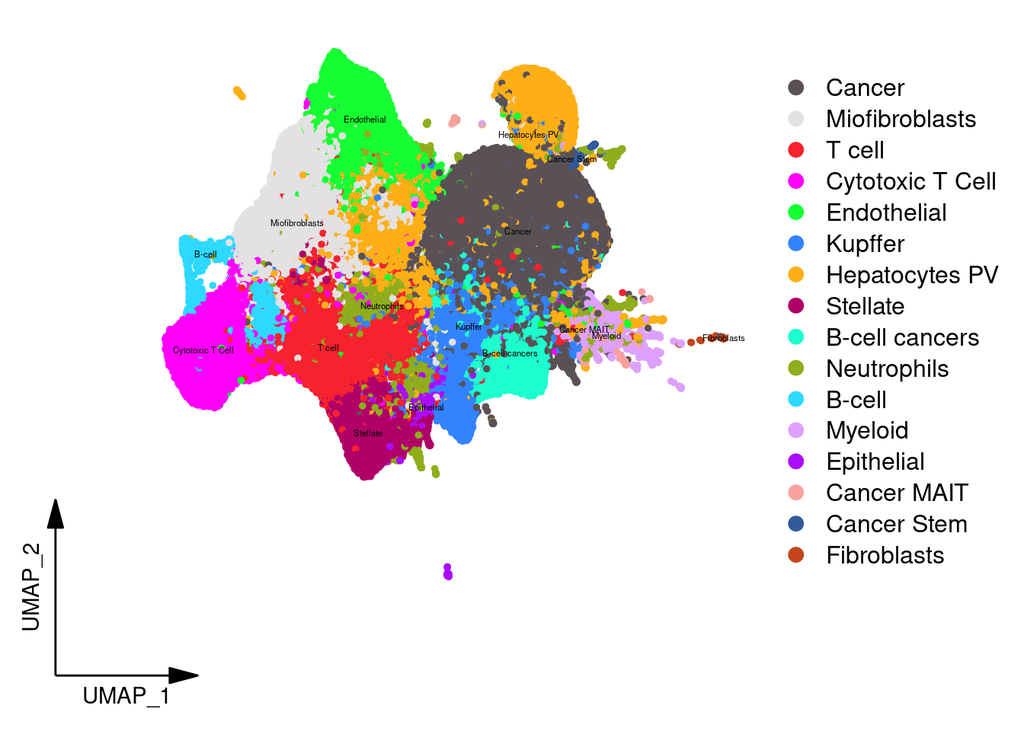

```r
# plot with clusters names
DimPlot_scCustom(seurat_object = analysis_renamed, reduction = "umap", label = TRUE, figure_plot = TRUE,
    pt.size = 1, label.size = 1.5, raster = F) + NoLegend()
```

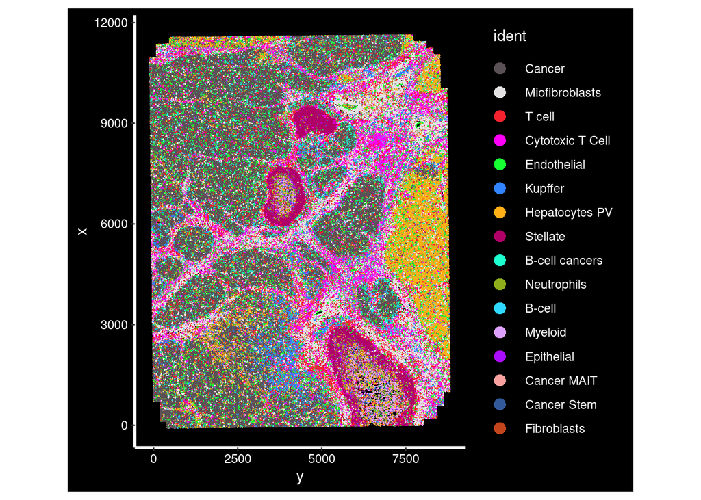

```r
ImageDimPlot(analysis_renamed, fov = "Human_liver_cancer1", cols = "polychrome", axes = TRUE)
```

Customizing spatial plots in Seurat with the `ImageDimPlot()` and `ImageFeaturePlot()`

Since it can be difficult to visualize the spatial localization patterns of an individual cluster when viewing them all together, we can highlight all cells that belong to a particular cluster:

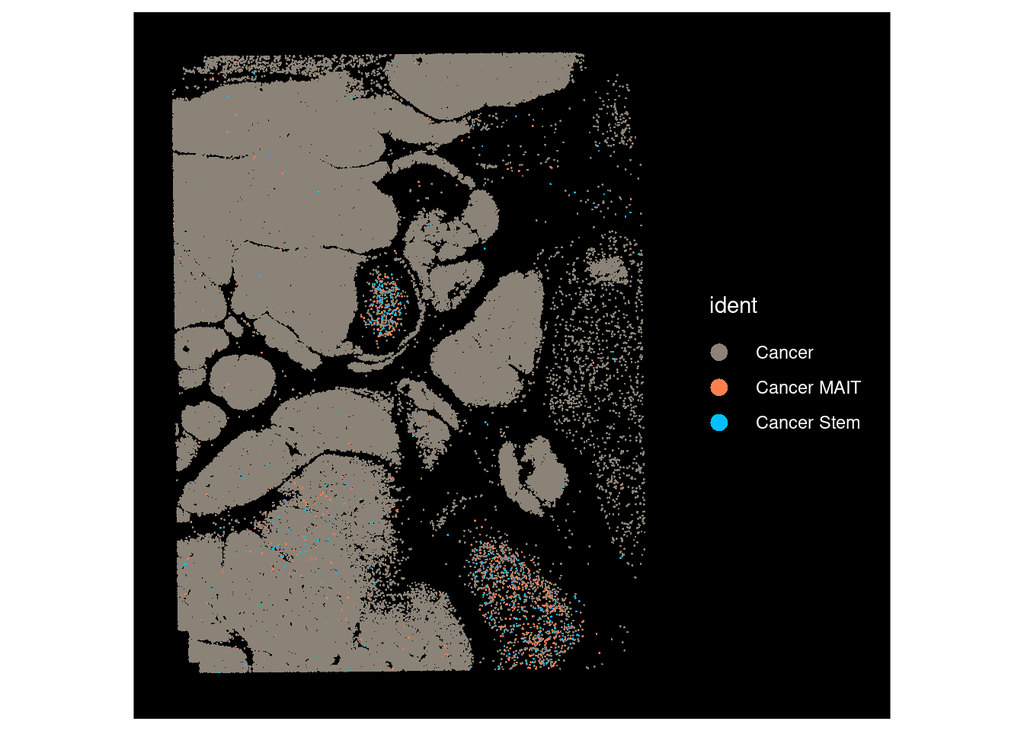

```r
p_can <- ImageDimPlot(analysis_renamed, fov = "Human_liver_cancer1", cols = c("antiquewhite4", "coral",
    "deepskyblue1"), cells = WhichCells(analysis_renamed, idents = c("Cancer", "Cancer MAIT", "Cancer Stem")))
p_can
```

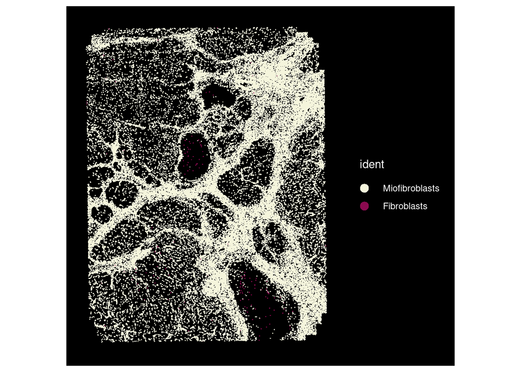

```r
p_mio <- ImageDimPlot(analysis_renamed, fov = "Human_liver_cancer1", cols = c("beige", "deeppink4"),
    cells = WhichCells(analysis_renamed, idents = c("Miofibroblasts", "Fibroblasts")))
p_mio
```

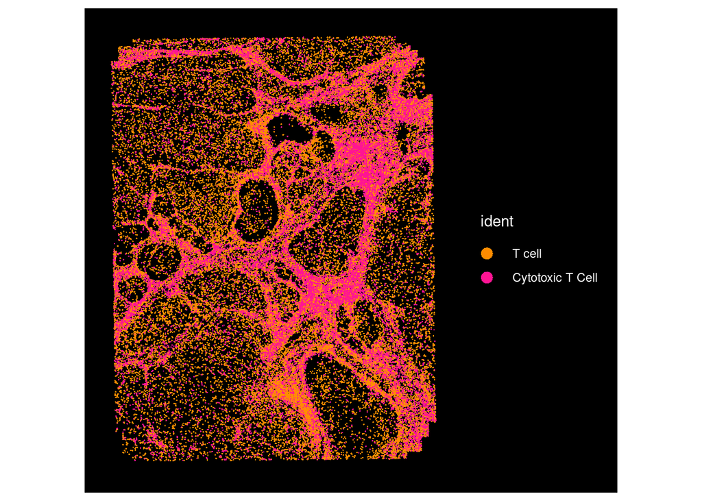

```r
p_T_cell <- ImageDimPlot(analysis_renamed, fov = "Human_liver_cancer1", cols = c("darkorange", "deeppink"),
    cells = WhichCells(analysis_renamed, idents = c("T cell", "Cytotoxic T Cell")))
p_T_cell
```

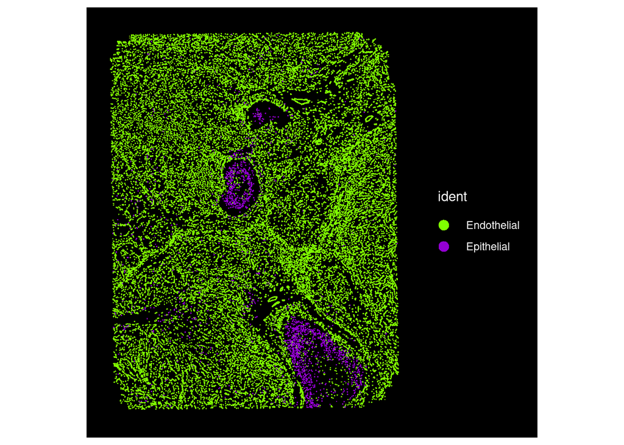

```r
p_endo <- ImageDimPlot(analysis_renamed, fov = "Human_liver_cancer1", cols = c("chartreuse", "darkviolet"),
    cells = WhichCells(analysis_renamed, idents = c("Endothelial", "Epithelial")))
p_endo
```

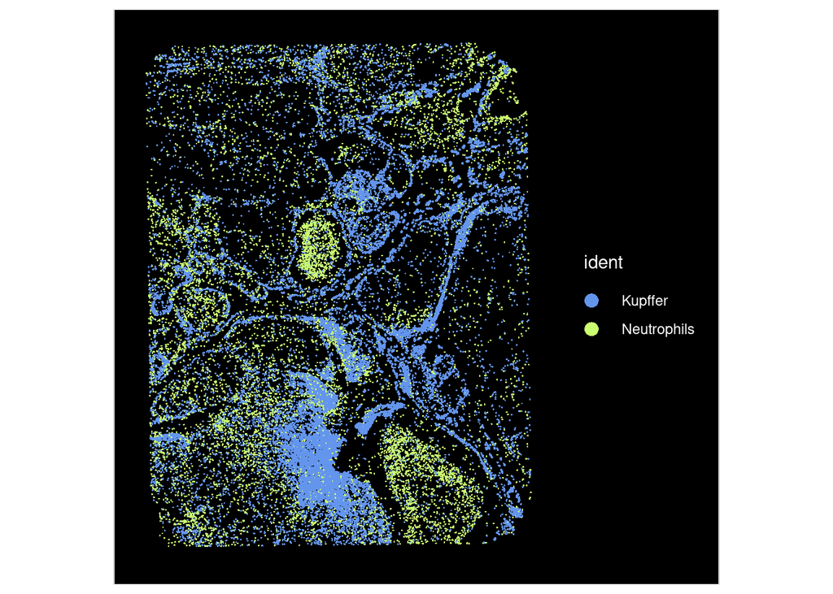

```r
p_imun <- ImageDimPlot(analysis_renamed, fov = "Human_liver_cancer1", cols = c("cornflowerblue",
    "darkolivegreen1"), cells = WhichCells(analysis_renamed, idents = c("Kupffer", "Neutrophils")))
p_imun
```

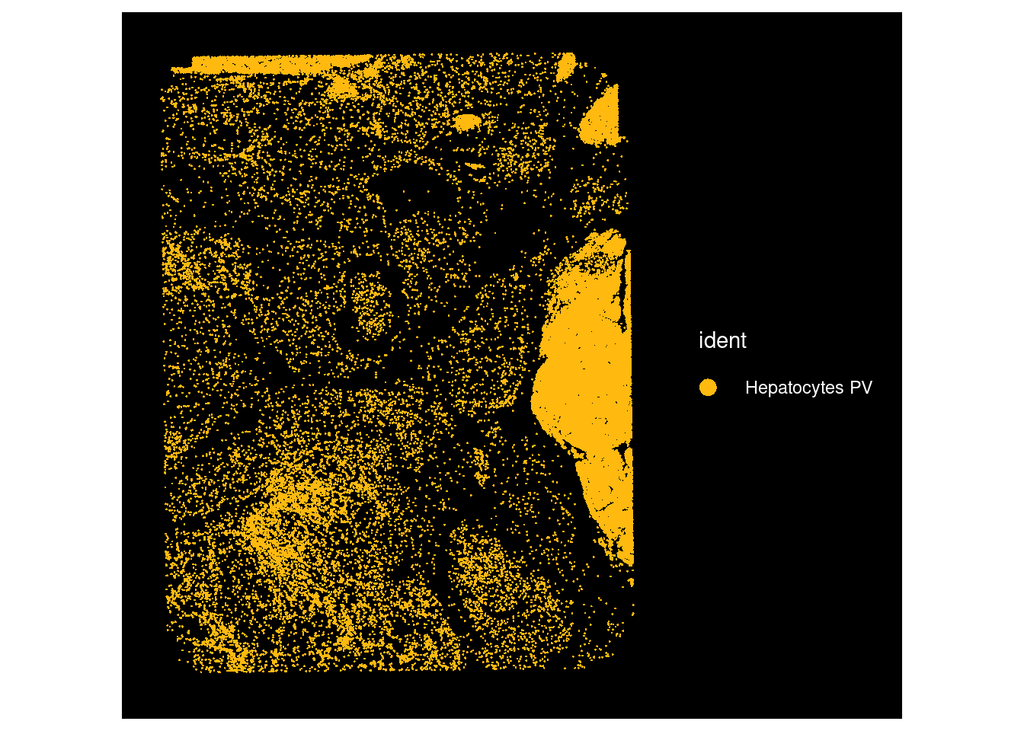

```r
p_hepPV <- ImageDimPlot(analysis_renamed, fov = "Human_liver_cancer1", cols = "darkgoldenrod1",
    cells = WhichCells(analysis_renamed, idents = "Hepatocytes PV"))
p_hepPV
```

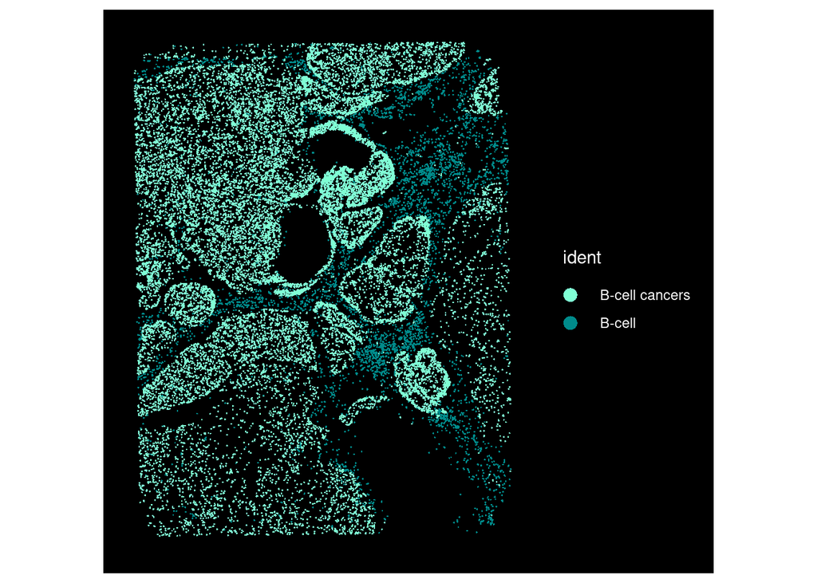

```r
p_B_cell <- ImageDimPlot(analysis_renamed, fov = "Human_liver_cancer1", cols = c("aquamarine", "cyan4"),
    cells = WhichCells(analysis_renamed, idents = c("B-cell cancers", "B-cell")))

p_B_cell
```

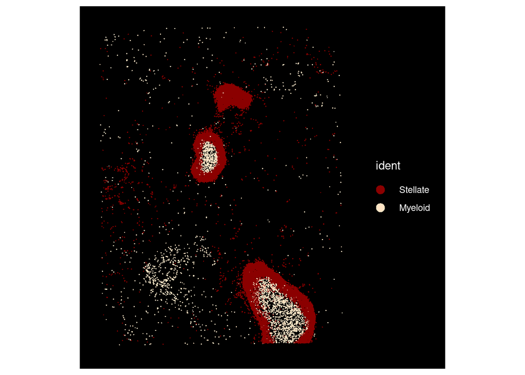

```r
p_stell <- ImageDimPlot(analysis_renamed, fov = "Human_liver_cancer1", cols = c("darkred", "bisque"),
    cells = WhichCells(analysis_renamed, idents = c("Stellate", "Myeloid")))

p_stell
```